# Informational and Navigational Searches Classifier

Isabel D'Alessandro CS 234

Install necessary packages

```python
!pip install nltk
import nltk
import string

from selenium import webdriver
from selenium.webdriver.common.keys import Keys

import time
import random
import codecs
from collections import Counter
from sklearn.feature_extraction.text import TfidfVectorizer

import itertools
import numpy as np
import matplotlib.pyplot as plt

from sklearn import svm, datasets
from sklearn.model_selection import train_test_split
from sklearn.metrics import confusion_matrix
```

### Exploring features of search queries

In order to determine which queries are informational and which are navigational, the classifier will have to be trained using particualr features of these queries. Some simple features include the **number of characters in the query**, **number of words in the query**, and whether the **query starts with a question word**(like 'who',what','when',etc). Below is a simple function to extract these features from a given search phrase:

```python
questionWords=['who','what','when','where','why','is','does','how','who','are']


def extractFeatures(phrase):
    my_dict={'num_chars': len(phrase),
             'num_words':len(phrase.split()),
             'question':phrase.split()[0].lower() in questionWords}
    return my_dict

#Example
extractFeatures('bates hall wellesley college')
```

```
{'num_chars': 28, 'num_words': 4, 'question': False}
```

Another feature of the search queries that we explored was the number of words of a particular **part of speech**(noun,verb, adjective, etc). We used the **nltk.pos_tag** function to extract the number of each part of speech in a given search phrase

```python
nltk.download('punkt')
nltk.download('averaged_perceptron_tagger')

postags=["$","''","(:","):",",","--",".",":","CC","CD","DT","EX","FW","IN","JJ","JJR","JJS","LS","MD","NN",
        "NNP","NNPS","NNS","PDT","POS","PRP","PRP$","RB","RBR","RBS","RP","SYM","TO","UH","VB","VBD",
        "VBG","VBN","VBP","VBZ","WDT","WP","WP$","WRB","``"]

def getPOS(phrase):
    tokens = nltk.word_tokenize(phrase.lower())
    text = nltk.Text(tokens)
    tagged = nltk.pos_tag(text)
    counts = Counter(tag for word,tag in tagged)
    for pos in postags:
        if pos not in counts.keys():
            counts[pos]=0
    total = sum(counts.values())
    return dict((word, float(count)/total) for word,count in counts.items())
```

Here is a feature extractor which incorporates all of the parts of speech:

```python
def extractFeatures2(phrase):
    my_dict={'num_chars': len(phrase),
             'num_words':len(phrase.split()),
             'question':phrase.split()[0].lower() in questionWords}
    pos=getPOS(phrase)
    my_dict.update(pos)
    return my_dict

#Example
extractFeatures('bates hall wellesley college')
```

```
{'num_chars': 28, 'num_words': 4, 'question': False}
```

This returns a dictionary with 45 parts of speech. We can try training the classifier using the counts of all of these parts of speech as features. However, because there are so many of them, we also run the risk of overwleming the other features, and of having a feature set that it too sparse. To get around this issue, let's also define another function to extract only the counts of three major parts of speech categories: noun, adjective, and verb:

```python
def getPOS3(phrase):
    adj=['JJ','JJR','JJS']
    noun=['NN','NNP','NNS']
    verb=['VB','VBD','VBG','VBN','VBP','VBZ']
    tokens = nltk.word_tokenize(phrase.lower())
    text = nltk.Text(tokens)
    tagged = nltk.pos_tag(text)
    counts = Counter(tag for word,tag in tagged)
    for pos in postags:
        if pos not in counts.keys():
            counts[pos]=0
    anv_counts={'adj':counts['JJ']+counts['JJR']+counts['JJS'],
           'noun':counts['NN']+counts['NNP']+counts['NNS'],
           'verb':counts['VB']+counts['VBD']+counts['VBG']+counts['VBN']+counts['VBP']+counts['VBZ']}
    anv_counts_total=float(anv_counts['adj']+anv_counts['noun']+anv_counts['verb'])
    anv_norm={'adj':anv_counts['adj']/anv_counts_total, 'noun':anv_counts['noun']/anv_counts_total,
              'verb':anv_counts['verb']/anv_counts_total}
    return anv_norm
```

Here is a feature extractor which incorporates only these three parts of speech as features:

```python
def extractFeatures3(phrase):
    my_dict={'num_chars': len(phrase),
             'num_words':len(phrase.split()),
             'question':phrase.split()[0].lower() in questionWords}
    pos=getPOS3(phrase)
    my_dict.update(pos)
    return my_dict

#Example
extractFeatures('bates hall wellesley college')
```

```
{'num_chars': 28, 'num_words': 4, 'question': False}
```

In addition to looking at the features of the search query itself, we can also look at the google search page that the query produces to try to identify if the search query is informational or navigational. Using **selenium**, we can extract featurs of the search results page, including the links, titles of the search results, and snippets of the returned pages. Let's do that first:

```python
def extractLinkAndText(item):
    """Extract link HREF and anchor text for a Google search result."""
    try:
        a = item.find_element_by_tag_name("a")
        return {"link": a.get_attribute("href"), "title": a.text}
    except: # in case we get errors
        return {"link": '', "title": ''}

def extractTextSnippet(item):
    """Returns text from an item."""
    return item.text
```

```python
from selenium import webdriver
browser = webdriver.Chrome(executable_path='/Users/isabeldalessandro/Downloads/chromedriver')
```

```python
def getWebpage(phrase):
    """Returns a dictionary with the link, title, and snippet of each returned result"""
    #browser = webdriver.Chrome(executable_path='/Users/isabeldalessandro/Downloads/chromedriver')
    browser.get('http://google.com')
    inputBox = browser.find_element_by_name("q")
    inputBox.clear()
    inputBox.send_keys(str(phrase))
    inputBox.send_keys(Keys.ENTER)
    time.sleep(3)
    rawHtml = browser.page_source
    linkDictsList = map(extractLinkAndText, browser.find_elements_by_class_name("rc"))
    snippetsList = map(extractTextSnippet, browser.find_elements_by_class_name("st"))
    allInfoDictsList = []
    for i, dct in enumerate(linkDictsList):
        dct['snippet'] = snippetsList[i] # add the snippet to the link and title
        allInfoDictsList.append(dct)
    return allInfoDictsList
```

One idea that we had was to look at the simialrity of the query to the returned link/title/snippet. For example, a navigational search for 'facebook' would likely yield a top result with the title and url of the same name, while an informational search like 'what is the capital of north dakota' wouldn't have a top result with such a url or title. We decided to look only at the first result, since we assumed that a navigational search would be likely to return the intended website as the first result. To quantify the similarity between a query and it's results, we represented all of the strings(search query, title, url, snippet) as Tfidf vectors, and calculated the cosine similarity between the search query and each of the other three features.

```python
stemmer = nltk.stem.porter.PorterStemmer()
remove_punctuation_map = dict((ord(char), None) for char in string.punctuation)

def stem_tokens(tokens):
    return [stemmer.stem(item) for item in tokens]

'''remove punctuation, lowercase, stem'''
def normalize(text):
    return stem_tokens(nltk.word_tokenize(text.lower().translate(remove_punctuation_map)))

vectorizer = TfidfVectorizer(tokenizer=normalize, stop_words='english')

def cosine_sim(text1, text2):
    """Calculate the cosine similairty between two texts """
    tfidf = vectorizer.fit_transform([text1, text2])
    return ((tfidf * tfidf.T).A)[0,1]
```

Here is another function to extract features that includes the similarity of the search query with attributes of the first search result:

```python
def extractFeatures4(phrase):
    my_dict={'num_chars': len(phrase),
             'num_words':len(phrase.split()),
             'question':phrase.split()[0].lower() in questionWords,
            'fullurlsim':cosine_sim(phrase,getWebpage(phrase)[1]['link']),#similarity of query and full url
            'mainurlsim':cosine_sim(phrase,getWebpage(phrase)[1]['link'].split('/')[2]),#similariy of the query and first part of the url
            'titlesim':cosine_sim(phrase,getWebpage(phrase)[1]['title']),#similariy of query and title
            'snippetsim':cosine_sim(phrase,getWebpage(phrase)[1]['snippet'])}#similarity of query and snippet
    pos=getPOS3(phrase)
    my_dict.update(pos)
    return my_dict

#Example
extractFeatures('bates hall wellesley college')
```

```
{'num_chars': 28, 'num_words': 4, 'question': False}
```

### Loading in the data

To train the classifier, we will use search queries about wellesley college which have been collected and hand-labeled by our class as either 'navigational'(n) or 'informational'(i)

```python
import csv
reader = csv.reader(open("labeled-data-final.csv", "rb"), delimiter=",")
allqueries = list(reader)[1:]
nav = list(filter(lambda x: x[1]=='n', allqueries))
inf = list(filter(lambda x: x[1]=='i', allqueries))
print 'navigational: '+str(len(nav))
print 'informational: '+str(len(inf))
```

```
navigational: 83
informational: 124
```

To make sure that the classifier is distinguishing between informational and navigational queries based on their featrues (and not just based on their relative frequencies in the dataset), it is important to create balanced datasets, that is, datasets with equal numbers of navigational and informational queries. We will also divide the data up into three sets: a **training set**(~80% of the data), **development set**(~10% of the data), and **testing set**(~10% of the data)

```python
nav=[(elem[0],elem[1]) for elem in nav]
inf=[(elem[0],elem[1]) for elem in inf]
random.shuffle(nav)
random.shuffle(inf)
trainData = nav[:65] + inf[:65]
devData = nav[65:74] + inf[65:74]
testData = nav[74:83] + inf[74:83]
```

Before training the classifier, we will need to extract the features of each of the search queries in the training, development, and testing sets. Above, we created many different feature extractors to try out. Let's start with the simplest feature extractor, using only the length of the query(in words and characters), and whether it starts with a question word:

```python
random.shuffle(trainData)
random.shuffle(devData)
random.shuffle(testData)

trainfeatures=[]
for (n,g) in trainData:
    try:
        trainfeatures.append((extractFeatures(n),g))
    except:
        IndexError

devfeatures=[]
for (n,g) in devData:
    try:
        devfeatures.append((extractFeatures(n),g))
    except:
        IndexError

testfeatures=[]
for (n,g) in testData:
    try:
        testfeatures.append((extractFeatures(n),g))
    except:
        IndexError
```

```python
#Save these featurized data vectors to files
import json
with open('trainfeatures.txt', 'w') as outfile:
    json.dump(trainfeatures, outfile)
with open('devfeatures.txt', 'w') as outfile:
    json.dump(devfeatures, outfile)
with open('testfeatures.txt', 'w') as outfile:
    json.dump(testfeatures, outfile)
```

### Training the Classifier

There are many different types of classifiers that we can try. Lets start by using a NaiveBayesClassifier.

```python
classifier = nltk.NaiveBayesClassifier.train(trainfeatures)
```

Let's see how the classifier does for a few sample data points:

```python
for query, label in testData[:5]:
    print (query, label), "labeled as:", classifier.classify(extractFeatures(query))
```

```
('brandeis wellesley orchestra', 'n') labeled as: i
('wellesley academic calendar 2017-2018', 'n') labeled as: n
('wellesley room and board', 'i') labeled as: n
('wellesley early decision acceptance rate', 'i') labeled as: i
('wellesley college average gpa', 'i') labeled as: i
```

### Testing the Classifier

```python
nltk.classify.accuracy(classifier, devfeatures)
```

```
0.6111111111111112
```

```python
nltk.classify.accuracy(classifier, testfeatures)
```

```
0.6666666666666666
```

```python
classifier.show_most_informative_features(2)
```

```
Most Informative Features
               num_chars = 27                  n : i      =      5.0 : 1.0
               num_chars = 36                  n : i      =      4.3 : 1.0
```

Find the predicted labels for the test data

```python
predictedlabels=[]
truelabels=[]
for query, label in testData:
    print query
    try:
        predictedlabels.append(classifier.classify(extractFeatures(query)))
        truelabels.append(label)
    except:
        IndexError
```

```
brandeis wellesley orchestra
wellesley academic calendar 2017-2018
wellesley room and board
wellesley early decision acceptance rate
wellesley college average gpa
wellesley science center
wellesley college music faculty
wellesley college grade deflation
wellesley multicultural requirement
does wellesley superscore sat
wellesley chemical physics
discover wellesley weekend schedule
wellesley college finance
wellesley college bates hall
wellesley college course catalog
wellesley college out of state tuition
wellesley alumnae magazine
wellesley college medical school
```

Plot confusion matrix

```python
%matplotlib inline

class_names=['navigational','informational']

def plot_confusion_matrix(cm, classes,
                          normalize=False,
                          title='Confusion matrix',
                          cmap=plt.cm.Blues):
    """
    This function prints and plots the confusion matrix.
    Normalization can be applied by setting `normalize=True`.
    """
    if normalize:
        cm = cm.astype('float') / cm.sum(axis=1)[:, np.newaxis]
        print("Normalized confusion matrix")
    else:
        print('Confusion matrix, without normalization')

    print(cm)

    plt.imshow(cm, interpolation='nearest', cmap=cmap)
    plt.title(title)
    plt.colorbar()
    tick_marks = np.arange(len(classes))
    plt.xticks(tick_marks, classes, rotation=45)
    plt.yticks(tick_marks, classes)

    fmt = '.2f' if normalize else 'd'
    thresh = cm.max() / 2.
    for i, j in itertools.product(range(cm.shape[0]), range(cm.shape[1])):
        plt.text(j, i, format(cm[i, j], fmt),
                 horizontalalignment="center",
                 color="white" if cm[i, j] > thresh else "black")

    plt.tight_layout()
    plt.ylabel('True label')
    plt.xlabel('Predicted label')
```

```
Confusion matrix, without normalization
[[7 2]
 [4 5]]
Normalized confusion matrix
[[ 0.78  0.22]
 [ 0.44  0.56]]
```

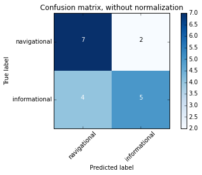

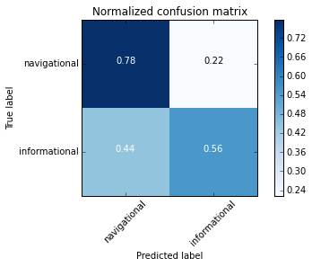

```python
# Compute confusion matrix
cnf_matrix = confusion_matrix(truelabels, predictedlabels)
np.set_printoptions(precision=2)

# Plot non-normalized confusion matrix
plt.figure()
plot_confusion_matrix(cnf_matrix, classes=class_names,
                      title='Confusion matrix, without normalization')

# Plot normalized confusion matrix

plt.figure()
plot_confusion_matrix(cnf_matrix, classes=class_names, normalize=True,
                      title='Normalized confusion matrix')

plt.show()
```

Cross Validation:

```python
import random
random.seed(10)
from sklearn import cross_validation
cv = cross_validation.KFold(len(trainfeatures), n_folds=10, shuffle=False, random_state=None)

allAccuracies = []
for traincv, testcv in cv:
    classifier = nltk.NaiveBayesClassifier.train(trainfeatures[traincv[0]:traincv[len(traincv)-1]])
    accuracy = nltk.classify.util.accuracy(classifier, trainfeatures[testcv[0]:testcv[len(testcv)-1]])
    print "accuracy: {:.3f}".format(accuracy)
    allAccuracies.append(accuracy)

print "average accuracy: {:.3f}".format(sum(allAccuracies)/len(allAccuracies))
```

```
accuracy: 0.500
accuracy: 0.833
accuracy: 0.750
accuracy: 0.750
accuracy: 0.750
accuracy: 0.583
accuracy: 0.833
accuracy: 0.833
accuracy: 0.583
accuracy: 0.500
average accuracy: 0.692
```

There are many other types of classifiers that we can try. Below are some examples of classifiers trained and tested on the same data, and their associated testing accuracies.

### Other Classifiers

```python
from nltk.classify import SklearnClassifier
from sklearn.naive_bayes import BernoulliNB
from sklearn.svm import SVC
from sklearn.linear_model import LogisticRegression
from sklearn.linear_model import SGDClassifier
from sklearn.neighbors import KNeighborsClassifier
from sklearn.neural_network import MLPClassifier
```

```python
#Decision Tree Classifier
# classifier= nltk.classify.DecisionTreeClassifier.train(trainfeatures)
# nltk.classify.accuracy(classifier, testfeatures)
import random
random.seed(10)
from sklearn import cross_validation
cv = cross_validation.KFold(len(trainfeatures), n_folds=10, shuffle=False, random_state=None)

allAccuracies = []
for traincv, testcv in cv:
    classifier = nltk.DecisionTreeClassifier.train(trainfeatures[traincv[0]:traincv[len(traincv)-1]])
    accuracy = nltk.classify.util.accuracy(classifier, trainfeatures[testcv[0]:testcv[len(testcv)-1]])
    print "accuracy: {:.3f}".format(accuracy)
    allAccuracies.append(accuracy)

print "average accuracy: {:.3f}".format(sum(allAccuracies)/len(allAccuracies))
```

```
accuracy: 0.583
accuracy: 0.833
accuracy: 0.833
accuracy: 0.750
accuracy: 0.750
accuracy: 0.667
accuracy: 0.833
accuracy: 0.833
accuracy: 0.667
accuracy: 0.583
average accuracy: 0.733
```

```python
#Support Vector Machine Classifier
# classifier = SklearnClassifier(SVC(max_iter=1)).train(trainfeatures)
# nltk.classify.accuracy(classifier, testfeatures)
import random
random.seed(10)
from sklearn import cross_validation
cv = cross_validation.KFold(len(trainfeatures), n_folds=10, shuffle=False, random_state=None)

allAccuracies = []
for traincv, testcv in cv:
    classifier = SklearnClassifier(SVC(max_iter=1)).train(trainfeatures[traincv[0]:traincv[len(traincv)-1]])
    accuracy = nltk.classify.util.accuracy(classifier, trainfeatures[testcv[0]:testcv[len(testcv)-1]])
    print "accuracy: {:.3f}".format(accuracy)
    allAccuracies.append(accuracy)

print "average accuracy: {:.3f}".format(sum(allAccuracies)/len(allAccuracies))
```

```
accuracy: 0.583
accuracy: 0.583
accuracy: 0.417
accuracy: 0.667
accuracy: 0.167
accuracy: 0.417
accuracy: 0.583
accuracy: 0.583
accuracy: 0.417
accuracy: 0.500
average accuracy: 0.492
```

```python
#Logistic Regression
# classifier = SklearnClassifier(LogisticRegression(max_iter=1000)).train(trainfeatures)
# nltk.classify.accuracy(classifier, testfeatures)

import random
random.seed(10)
from sklearn import cross_validation
cv = cross_validation.KFold(len(trainfeatures), n_folds=10, shuffle=False, random_state=None)

allAccuracies = []
for traincv, testcv in cv:
    classifier = SklearnClassifier(LogisticRegression(max_iter=1000)).train(trainfeatures[traincv[0]:traincv[len(traincv)-1]])
    accuracy = nltk.classify.util.accuracy(classifier, trainfeatures[testcv[0]:testcv[len(testcv)-1]])
    print "accuracy: {:.3f}".format(accuracy)
    allAccuracies.append(accuracy)

print "average accuracy: {:.3f}".format(sum(allAccuracies)/len(allAccuracies))
```

```
accuracy: 0.333
accuracy: 0.667
accuracy: 0.583
accuracy: 0.333
accuracy: 0.750
accuracy: 0.750
accuracy: 0.333
accuracy: 0.667
accuracy: 0.750
accuracy: 0.667
average accuracy: 0.583
```

```python
#K-nearest neighbors
# classifier = SklearnClassifier(KNeighborsClassifier()).train(trainfeatures)
# nltk.classify.accuracy(classifier, testfeatures)

import random
random.seed(10)
from sklearn import cross_validation
cv = cross_validation.KFold(len(trainfeatures), n_folds=10, shuffle=False, random_state=None)

allAccuracies = []
for traincv, testcv in cv:
    classifier = SklearnClassifier(KNeighborsClassifier()).train(trainfeatures[traincv[0]:traincv[len(traincv)-1]])
    accuracy = nltk.classify.util.accuracy(classifier, trainfeatures[testcv[0]:testcv[len(testcv)-1]])
    print "accuracy: {:.3f}".format(accuracy)
    allAccuracies.append(accuracy)

print "average accuracy: {:.3f}".format(sum(allAccuracies)/len(allAccuracies))
```

```
accuracy: 0.500
accuracy: 0.667
accuracy: 0.667
accuracy: 0.667
accuracy: 0.833
accuracy: 0.583
accuracy: 0.750
accuracy: 0.667
accuracy: 0.667
accuracy: 0.667
average accuracy: 0.667
```

```python
#Multi-layer perceptron classifier using LBFGS optimization
# classifier = SklearnClassifier(MLPClassifier(activation='relu',solver='lbfgs',
#                                              alpha=1e-5,hidden_layer_sizes=(5, 4),
#                                              random_state=1)).train(trainfeatures)
#parameters determined through some hyperparameter tuning(not shown)
# nltk.classify.accuracy(classifier, testfeatures)

import random
random.seed(10)
from sklearn import cross_validation
cv = cross_validation.KFold(len(trainfeatures), n_folds=10, shuffle=False, random_state=None)

allAccuracies = []
for traincv, testcv in cv:
    classifier = SklearnClassifier(MLPClassifier(activation='relu',solver='lbfgs',
                                             alpha=1e-5,hidden_layer_sizes=(5, 4),
                                             random_state=1)).train(trainfeatures[traincv[0]:traincv[len(traincv)-1]])
    accuracy = nltk.classify.util.accuracy(classifier, trainfeatures[testcv[0]:testcv[len(testcv)-1]])
    print "accuracy: {:.3f}".format(accuracy)
    allAccuracies.append(accuracy)

print "average accuracy: {:.3f}".format(sum(allAccuracies)/len(allAccuracies))
```

```
accuracy: 0.333
accuracy: 0.500
accuracy: 0.583
accuracy: 0.417
accuracy: 0.833
accuracy: 0.667
accuracy: 0.500
accuracy: 0.417
accuracy: 0.583
accuracy: 0.417
average accuracy: 0.525
```

### Testing Other Feature Extractors

We can repeat the process above for other feature extractor functions to see if we can achieve a better accuracy

**extractFeatures2**

```python
random.shuffle(nav)
random.shuffle(inf)
nav=[(elem[0],elem[1]) for elem in nav]
inf=[(elem[0],elem[1]) for elem in inf]
trainData = nav[:65] + inf[:65]
devData = nav[65:74] + inf[65:74]
testData = nav[74:83] + inf[74:83]
```

```python
random.shuffle(trainData)
random.shuffle(devData)
random.shuffle(testData)

trainfeatures2=[]
for (n,g) in trainData:
    try:
        trainfeatures2.append((extractFeatures2(n),g))
    except:
        IndexError

devfeatures2=[]
for (n,g) in devData:
    try:
        devfeatures2.append((extractFeatures2(n),g))
    except:
        IndexError

testfeatures2=[]
for (n,g) in testData:
    try:
        testfeatures2.append((extractFeatures2(n),g))
    except:
        IndexError
```

```python
#Save these featurized data vectors to files
import json
with open('trainfeatures2.txt', 'w') as outfile:
    json.dump(trainfeatures2, outfile)
with open('devfeatures2.txt', 'w') as outfile:
    json.dump(devfeatures2, outfile)
with open('testfeatures2.txt', 'w') as outfile:
    json.dump(testfeatures2, outfile)
```

```python
#Naive Bayes Classifier
# classifier = nltk.NaiveBayesClassifier.train(trainfeatures2)
# nltk.classify.accuracy(classifier, testfeatures2)

import random
random.seed(10)
from sklearn import cross_validation
cv = cross_validation.KFold(len(trainfeatures2), n_folds=10, shuffle=False, random_state=None)

allAccuracies = []
for traincv, testcv in cv:
    classifier = nltk.NaiveBayesClassifier.train(trainfeatures2[traincv[0]:traincv[len(traincv)-1]])
    accuracy = nltk.classify.util.accuracy(classifier, trainfeatures2[testcv[0]:testcv[len(testcv)-1]])
    print "accuracy: {:.3f}".format(accuracy)
    allAccuracies.append(accuracy)

print "average accuracy: {:.3f}".format(sum(allAccuracies)/len(allAccuracies))
```

```
accuracy: 0.833
accuracy: 0.917
accuracy: 0.750
accuracy: 0.750
accuracy: 0.917
accuracy: 0.833
accuracy: 0.750
accuracy: 1.000
accuracy: 0.750
accuracy: 0.667
average accuracy: 0.817
```

Plot a confusion matrix

```
Confusion matrix, without normalization
[[5 4]
 [1 8]]
Normalized confusion matrix
[[ 0.56  0.44]
 [ 0.11  0.89]]
```

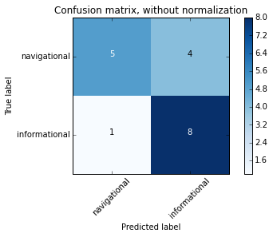

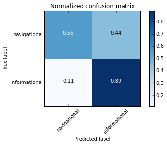

```python
predictedlabels=[]
truelabels=[]
for query, label in testData:
    try:
        predictedlabels.append(classifier.classify(extractFeatures2(query)))
        truelabels.append(label)
    except:
        IndexError

# Compute confusion matrix
cnf_matrix = confusion_matrix(truelabels, predictedlabels)
np.set_printoptions(precision=2)

# Plot non-normalized confusion matrix
plt.figure()
plot_confusion_matrix(cnf_matrix, classes=class_names,
                      title='Confusion matrix, without normalization')

# Plot normalized confusion matrix

plt.figure()
plot_confusion_matrix(cnf_matrix, classes=class_names, normalize=True,
                      title='Normalized confusion matrix')

plt.show()
```

```python
#Decision Tree Classifier
# classifier= nltk.classify.DecisionTreeClassifier.train(trainfeatures2)
# nltk.classify.accuracy(classifier, testfeatures2)

import random
random.seed(10)
from sklearn import cross_validation
cv = cross_validation.KFold(len(trainfeatures2), n_folds=10, shuffle=False, random_state=None)

allAccuracies = []
for traincv, testcv in cv:
    classifier= nltk.classify.DecisionTreeClassifier.train(trainfeatures2[traincv[0]:traincv[len(traincv)-1]])
    accuracy = nltk.classify.util.accuracy(classifier, trainfeatures2[testcv[0]:testcv[len(testcv)-1]])
    print "accuracy: {:.3f}".format(accuracy)
    allAccuracies.append(accuracy)

print "average accuracy: {:.3f}".format(sum(allAccuracies)/len(allAccuracies))
```

```
accuracy: 0.500
accuracy: 1.000
accuracy: 0.833
accuracy: 1.000
accuracy: 1.000
accuracy: 0.833
accuracy: 1.000
accuracy: 0.750
accuracy: 0.833
accuracy: 0.583
average accuracy: 0.833
```

```python
#Support Vector Machine Classifier
# classifier = SklearnClassifier(SVC(max_iter=1)).train(trainfeatures2)
# nltk.classify.accuracy(classifier, testfeatures2)

import random
random.seed(10)
from sklearn import cross_validation
cv = cross_validation.KFold(len(trainfeatures2), n_folds=10, shuffle=False, random_state=None)

allAccuracies = []
for traincv, testcv in cv:
    classifier = SklearnClassifier(SVC(max_iter=1)).train(trainfeatures2[traincv[0]:traincv[len(traincv)-1]])
    accuracy = nltk.classify.util.accuracy(classifier, trainfeatures2[testcv[0]:testcv[len(testcv)-1]])
    print "accuracy: {:.3f}".format(accuracy)
    allAccuracies.append(accuracy)

print "average accuracy: {:.3f}".format(sum(allAccuracies)/len(allAccuracies))
```

```
accuracy: 0.250
accuracy: 0.417
accuracy: 0.667
accuracy: 0.417
accuracy: 0.583
accuracy: 0.417
accuracy: 0.667
accuracy: 0.417
accuracy: 0.667
accuracy: 0.500
average accuracy: 0.500
```

```python
#Logistic Regression
# classifier = SklearnClassifier(LogisticRegression(max_iter=1000)).train(trainfeatures2)
# nltk.classify.accuracy(classifier, testfeatures2)

import random
random.seed(10)
from sklearn import cross_validation
cv = cross_validation.KFold(len(trainfeatures2), n_folds=10, shuffle=False, random_state=None)

allAccuracies = []
for traincv, testcv in cv:
    classifier = SklearnClassifier(LogisticRegression(max_iter=1000)).train(trainfeatures2[traincv[0]:traincv[len(traincv)-1]])
    accuracy = nltk.classify.util.accuracy(classifier, trainfeatures2[testcv[0]:testcv[len(testcv)-1]])
    print "accuracy: {:.3f}".format(accuracy)
    allAccuracies.append(accuracy)

print "average accuracy: {:.3f}".format(sum(allAccuracies)/len(allAccuracies))
```

```
accuracy: 0.667
accuracy: 0.833
accuracy: 0.583
accuracy: 0.667
accuracy: 0.750
accuracy: 0.583
accuracy: 0.583
accuracy: 0.750
accuracy: 0.750
accuracy: 0.583
average accuracy: 0.675
```

```python
#K-nearest neighbors
# classifier = SklearnClassifier(KNeighborsClassifier()).train(trainfeatures2)
# nltk.classify.accuracy(classifier, testfeatures2)

random.seed(10)
from sklearn import cross_validation
cv = cross_validation.KFold(len(trainfeatures2), n_folds=10, shuffle=False, random_state=None)

allAccuracies = []
for traincv, testcv in cv:
    classifier = SklearnClassifier(KNeighborsClassifier()).train(trainfeatures2[traincv[0]:traincv[len(traincv)-1]])
    accuracy = nltk.classify.util.accuracy(classifier, trainfeatures2[testcv[0]:testcv[len(testcv)-1]])
    print "accuracy: {:.3f}".format(accuracy)
    allAccuracies.append(accuracy)

print "average accuracy: {:.3f}".format(sum(allAccuracies)/len(allAccuracies))
```

```
accuracy: 0.583
accuracy: 0.917
accuracy: 0.500
accuracy: 0.833
accuracy: 0.917
accuracy: 0.583
accuracy: 0.750
accuracy: 0.750
accuracy: 0.583
accuracy: 0.583
average accuracy: 0.700
```

```python
#Multi-layer perceptron classifier using LBFGS optimization
# classifier = SklearnClassifier(MLPClassifier(activation='relu',solver='lbfgs',
#                                              alpha=1e-5,hidden_layer_sizes=(5, 4),
#                                              random_state=1)).train(trainfeatures2)
#parameters determined through some hyperparameter tuning(not shown)
#nltk.classify.accuracy(classifier, testfeatures2)

random.seed(10)
from sklearn import cross_validation
cv = cross_validation.KFold(len(trainfeatures2), n_folds=10, shuffle=False, random_state=None)

allAccuracies = []
for traincv, testcv in cv:
    classifier = SklearnClassifier(MLPClassifier(activation='relu',solver='lbfgs',
                                             alpha=1e-5,hidden_layer_sizes=(5, 4),
                                             random_state=1)).train(trainfeatures2[traincv[0]:traincv[len(traincv)-1]])
    accuracy = nltk.classify.util.accuracy(classifier, trainfeatures2[testcv[0]:testcv[len(testcv)-1]])
    print "accuracy: {:.3f}".format(accuracy)
    allAccuracies.append(accuracy)

print "average accuracy: {:.3f}".format(sum(allAccuracies)/len(allAccuracies))
```

```
accuracy: 0.667
accuracy: 0.917
accuracy: 0.667
accuracy: 0.500
accuracy: 0.750
accuracy: 0.667
accuracy: 0.583
accuracy: 0.667
accuracy: 0.750
accuracy: 0.583
average accuracy: 0.675
```

**extractFeatures3**

```python
random.shuffle(nav)
random.shuffle(inf)
nav=[(elem[0],elem[1]) for elem in nav]
inf=[(elem[0],elem[1]) for elem in inf]
trainData = nav[:65] + inf[:65]
devData = nav[65:74] + inf[65:74]
testData = nav[74:83] + inf[74:83]
```

```python
random.shuffle(trainData)
random.shuffle(devData)
random.shuffle(testData)

trainfeatures3=[]
for (n,g) in trainData:
    try:
        trainfeatures3.append((extractFeatures3(n),g))
    except:
        IndexError

devfeatures3=[]
for (n,g) in devData:
    try:
        devfeatures3.append((extractFeatures3(n),g))
    except:
        IndexError

testfeatures3=[]
for (n,g) in testData:
    try:
        testfeatures3.append((extractFeatures3(n),g))
    except:
        IndexError
```

```python
#Save these featurized data vectors to files
import json
with open('trainfeatures3.txt', 'w') as outfile:
    json.dump(trainfeatures3, outfile)
with open('devfeatures3.txt', 'w') as outfile:
    json.dump(devfeatures3, outfile)
with open('testfeatures3.txt', 'w') as outfile:
    json.dump(testfeatures3, outfile)
```

```python
#Naive Bayes Classifier
# classifier = nltk.NaiveBayesClassifier.train(trainfeatures3)
# print 'Naive Bayes Classifier'
# nltk.classify.accuracy(classifier, testfeatures3)

random.seed(10)
from sklearn import cross_validation
cv = cross_validation.KFold(len(trainfeatures3), n_folds=10, shuffle=False, random_state=None)

allAccuracies = []
for traincv, testcv in cv:
    classifier = nltk.NaiveBayesClassifier.train(trainfeatures3[traincv[0]:traincv[len(traincv)-1]])
    accuracy = nltk.classify.util.accuracy(classifier, trainfeatures3[testcv[0]:testcv[len(testcv)-1]])
    print "accuracy: {:.3f}".format(accuracy)
    allAccuracies.append(accuracy)

print "average accuracy: {:.3f}".format(sum(allAccuracies)/len(allAccuracies))
```

```
accuracy: 0.417
accuracy: 1.000
accuracy: 0.500
accuracy: 0.833
accuracy: 0.833
accuracy: 0.833
accuracy: 0.667
accuracy: 0.917
accuracy: 0.750
accuracy: 0.667
average accuracy: 0.742
```

```
Confusion matrix, without normalization
[[8 1]
 [3 6]]
Normalized confusion matrix
[[ 0.89  0.11]
 [ 0.33  0.67]]
```

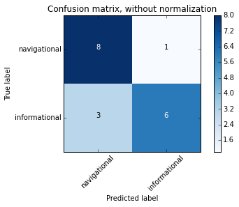

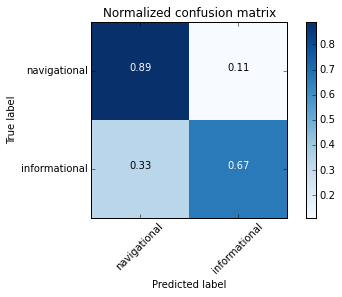

```python
predictedlabels=[]
truelabels=[]
for query, label in testData:
    try:
        predictedlabels.append(classifier.classify(extractFeatures3(query)))
        truelabels.append(label)
    except:
        IndexError

# Compute confusion matrix
cnf_matrix = confusion_matrix(truelabels, predictedlabels)
np.set_printoptions(precision=2)

# Plot non-normalized confusion matrix
plt.figure()
plot_confusion_matrix(cnf_matrix, classes=class_names,
                      title='Confusion matrix, without normalization')

# Plot normalized confusion matrix

plt.figure()
plot_confusion_matrix(cnf_matrix, classes=class_names, normalize=True,
                      title='Normalized confusion matrix')

plt.show()
```

```python
#Decision Tree Classifier
#classifier= nltk.classify.DecisionTreeClassifier.train(trainfeatures3)
print 'Decision Tree Classifier'
#print nltk.classify.accuracy(classifier, testfeatures3)



random.seed(10)
from sklearn import cross_validation
cv = cross_validation.KFold(len(trainfeatures3), n_folds=10, shuffle=False, random_state=None)

allAccuracies = []
for traincv, testcv in cv:
    classifier= nltk.classify.DecisionTreeClassifier.train(trainfeatures3[traincv[0]:traincv[len(traincv)-1]])
    accuracy = nltk.classify.util.accuracy(classifier, trainfeatures3[testcv[0]:testcv[len(testcv)-1]])
    print "accuracy: {:.3f}".format(accuracy)
    allAccuracies.append(accuracy)

print "average accuracy: {:.3f}".format(sum(allAccuracies)/len(allAccuracies))



#Support Vector Machine Classifier
#classifier = SklearnClassifier(SVC(max_iter=1)).train(trainfeatures3)
print 'Support Vector Machine Classifier'
#print nltk.classify.accuracy(classifier, testfeatures3)



cv = cross_validation.KFold(len(trainfeatures3), n_folds=10, shuffle=False, random_state=None)

allAccuracies = []
for traincv, testcv in cv:
    classifier = SklearnClassifier(SVC(max_iter=1)).train(trainfeatures3[traincv[0]:traincv[len(traincv)-1]])
    accuracy = nltk.classify.util.accuracy(classifier, trainfeatures3[testcv[0]:testcv[len(testcv)-1]])
    print "accuracy: {:.3f}".format(accuracy)
    allAccuracies.append(accuracy)

print "average accuracy: {:.3f}".format(sum(allAccuracies)/len(allAccuracies))


#Logistic Regression
#classifier = SklearnClassifier(LogisticRegression(max_iter=1000)).train(trainfeatures3)
print 'Logistic Regression'
#print nltk.classify.accuracy(classifier, testfeatures3)

cv = cross_validation.KFold(len(trainfeatures3), n_folds=10, shuffle=False, random_state=None)

allAccuracies = []
for traincv, testcv in cv:
    classifier = SklearnClassifier(LogisticRegression(max_iter=1000)).train(trainfeatures3[traincv[0]:traincv[len(traincv)-1]])
    accuracy = nltk.classify.util.accuracy(classifier, trainfeatures3[testcv[0]:testcv[len(testcv)-1]])
    print "accuracy: {:.3f}".format(accuracy)
    allAccuracies.append(accuracy)

print "average accuracy: {:.3f}".format(sum(allAccuracies)/len(allAccuracies))

#K-nearest neighbors
#classifier = SklearnClassifier(KNeighborsClassifier()).train(trainfeatures3)
print 'K-nearest neighbors'
#print nltk.classify.accuracy(classifier, testfeatures3)

cv = cross_validation.KFold(len(trainfeatures3), n_folds=10, shuffle=False, random_state=None)

allAccuracies = []
for traincv, testcv in cv:
    classifier = SklearnClassifier(KNeighborsClassifier()).train(trainfeatures3[traincv[0]:traincv[len(traincv)-1]])
    accuracy = nltk.classify.util.accuracy(classifier, trainfeatures3[testcv[0]:testcv[len(testcv)-1]])
    print "accuracy: {:.3f}".format(accuracy)
    allAccuracies.append(accuracy)

print "average accuracy: {:.3f}".format(sum(allAccuracies)/len(allAccuracies))

#Multi-layer perceptron classifier using LBFGS optimization
# classifier = SklearnClassifier(MLPClassifier(activation='relu',solver='lbfgs',
#                                              alpha=1e-5,hidden_layer_sizes=(5, 4),
#                                              random_state=1)).train(trainfeatures3)
#parameters determined through some hyperparameter tuning(not shown)
print 'Multi-layer perceptron classifier'
#print nltk.classify.accuracy(classifier, testfeatures3)


cv = cross_validation.KFold(len(trainfeatures3), n_folds=10, shuffle=False, random_state=None)

allAccuracies = []
for traincv, testcv in cv:
    classifier = SklearnClassifier(MLPClassifier(activation='relu',solver='lbfgs',
                                             alpha=1e-5,hidden_layer_sizes=(5, 4),
                                             random_state=1)).train(trainfeatures3[traincv[0]:traincv[len(traincv)-1]])
    accuracy = nltk.classify.util.accuracy(classifier, trainfeatures3[testcv[0]:testcv[len(testcv)-1]])
    print "accuracy: {:.3f}".format(accuracy)
    allAccuracies.append(accuracy)

print "average accuracy: {:.3f}".format(sum(allAccuracies)/len(allAccuracies))
```

```
Decision Tree Classifier
accuracy: 0.500
accuracy: 1.000
accuracy: 0.833
accuracy: 0.833
accuracy: 0.917
accuracy: 0.917
accuracy: 0.667
accuracy: 0.833
accuracy: 1.000
accuracy: 0.583
average accuracy: 0.808
Support Vector Machine Classifier
accuracy: 0.667
accuracy: 0.333
accuracy: 0.417
accuracy: 0.500
accuracy: 0.167
accuracy: 0.583
accuracy: 0.417
accuracy: 0.667
accuracy: 0.833
accuracy: 0.333
average accuracy: 0.492
Logistic Regression
accuracy: 0.417
accuracy: 0.750
accuracy: 0.417
accuracy: 0.833
accuracy: 0.417
accuracy: 0.667
accuracy: 0.333
accuracy: 0.750
accuracy: 0.333
accuracy: 0.583
average accuracy: 0.550
K-nearest neighbors
accuracy: 0.417
accuracy: 0.750
accuracy: 0.583
accuracy: 0.583
accuracy: 0.917
accuracy: 0.750
accuracy: 0.667
accuracy: 0.583
accuracy: 0.750
accuracy: 0.500
average accuracy: 0.650
Multi-layer perceptron classifier
accuracy: 0.333
accuracy: 0.750
accuracy: 0.500
accuracy: 0.417
accuracy: 0.750
accuracy: 0.500
accuracy: 0.583
accuracy: 0.417
accuracy: 0.167
accuracy: 0.417
average accuracy: 0.483
```

**extractFeatures4**

```python
random.shuffle(nav)
random.shuffle(inf)
nav=[(elem[0],elem[1]) for elem in nav]
inf=[(elem[0],elem[1]) for elem in inf]
trainData = nav[:65] + inf[:65]
devData = nav[65:74] + inf[65:74]
testData = nav[74:83] + inf[74:83]
```

```python
random.shuffle(trainData)
random.shuffle(devData)
random.shuffle(testData)

trainfeatures4=[]
for (n,g) in trainData:
    try:
        trainfeatures4.append((extractFeatures4(n),g))
    except:
        IndexError

devfeatures4=[]
for (n,g) in devData:
    try:
        devfeatures4.append((extractFeatures4(n),g))
    except:
        IndexError

testfeatures4=[]
for (n,g) in testData:
    try:
        testfeatures4.append((extractFeatures4(n),g))
    except:
        IndexError
```

```python
devfeatures4=[]
for (n,g) in devData:
    try:
        devfeatures4.append((extractFeatures4(n),g))
    except:
        IndexError
```

```python
testfeatures4=[]
for (n,g) in testData:
    try:
        testfeatures4.append((extractFeatures4(n),g))
    except:
        IndexError
```

```python
#Save these featurized data vectors to files
import json
with open('trainfeatures4.txt', 'w') as outfile:
    json.dump(trainfeatures4, outfile)
with open('devfeatures4.txt', 'w') as outfile:
    json.dump(devfeatures4, outfile)
with open('testfeatures4.txt', 'w') as outfile:
    json.dump(testfeatures4, outfile)
```

```python
#Naive Bayes Classifier
#classifier = nltk.NaiveBayesClassifier.train(trainfeatures4)
print 'Naive Bayes Classifier'
#nltk.classify.accuracy(classifier, testfeatures4)


cv = cross_validation.KFold(len(trainfeatures4), n_folds=10, shuffle=False, random_state=None)

allAccuracies = []
for traincv, testcv in cv:
    classifier = nltk.NaiveBayesClassifier.train(trainfeatures4[traincv[0]:traincv[len(traincv)-1]])
    accuracy = nltk.classify.util.accuracy(classifier, trainfeatures4[testcv[0]:testcv[len(testcv)-1]])
    print "accuracy: {:.3f}".format(accuracy)
    allAccuracies.append(accuracy)

print "average accuracy: {:.3f}".format(sum(allAccuracies)/len(allAccuracies))
```

```
Naive Bayes Classifier
accuracy: 0.444
accuracy: 1.000
accuracy: 1.000
accuracy: 0.889
accuracy: 0.778
accuracy: 0.889
accuracy: 0.889
accuracy: 0.667
accuracy: 0.889
accuracy: 0.556
average accuracy: 0.800
```

```
Confusion matrix, without normalization
[[4 2]
 [4 5]]
Normalized confusion matrix
[[ 0.67  0.33]
 [ 0.44  0.56]]
```

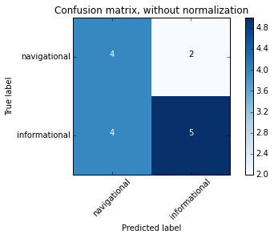

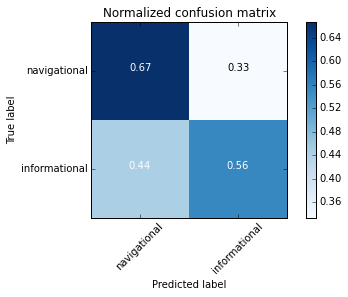

```python
predictedlabels=[]
truelabels=[]
for query, label in testData:
    try:
        predictedlabels.append(classifier.classify(extractFeatures4(query)))
        truelabels.append(label)
    except:
        IndexError

# Compute confusion matrix
cnf_matrix = confusion_matrix(truelabels, predictedlabels)
np.set_printoptions(precision=2)

# Plot non-normalized confusion matrix
plt.figure()
plot_confusion_matrix(cnf_matrix, classes=class_names,
                      title='Confusion matrix, without normalization')

# Plot normalized confusion matrix

plt.figure()
plot_confusion_matrix(cnf_matrix, classes=class_names, normalize=True,
                      title='Normalized confusion matrix')

plt.show()
```

```python
#Decision Tree Classifier
#classifier= nltk.classify.DecisionTreeClassifier.train(trainfeatures4)
print 'Decision Tree Classifier'
#nltk.classify.accuracy(classifier, testfeatures4)


cv = cross_validation.KFold(len(trainfeatures4), n_folds=10, shuffle=False, random_state=None)

allAccuracies = []
for traincv, testcv in cv:
    classifier= nltk.classify.DecisionTreeClassifier.train(trainfeatures4[traincv[0]:traincv[len(traincv)-1]])
    accuracy = nltk.classify.util.accuracy(classifier, trainfeatures4[testcv[0]:testcv[len(testcv)-1]])
    print "accuracy: {:.3f}".format(accuracy)
    allAccuracies.append(accuracy)

print "average accuracy: {:.3f}".format(sum(allAccuracies)/len(allAccuracies))

#Support Vector Machine Classifier
#classifier = SklearnClassifier(SVC(max_iter=1)).train(trainfeatures4)
print 'Support Vector Machine Classifier'
#nltk.classify.accuracy(classifier, testfeatures4)

cv = cross_validation.KFold(len(trainfeatures4), n_folds=10, shuffle=False, random_state=None)

allAccuracies = []
for traincv, testcv in cv:
    classifier = SklearnClassifier(SVC(max_iter=1)).train(trainfeatures4[traincv[0]:traincv[len(traincv)-1]])
    accuracy = nltk.classify.util.accuracy(classifier, trainfeatures4[testcv[0]:testcv[len(testcv)-1]])
    print "accuracy: {:.3f}".format(accuracy)
    allAccuracies.append(accuracy)

print "average accuracy: {:.3f}".format(sum(allAccuracies)/len(allAccuracies))

#Logistic Regression
#classifier = SklearnClassifier(LogisticRegression(max_iter=1000)).train(trainfeatures4)
print 'Logistic Regression'
#nltk.classify.accuracy(classifier, testfeatures4)

cv = cross_validation.KFold(len(trainfeatures4), n_folds=10, shuffle=False, random_state=None)

allAccuracies = []
for traincv, testcv in cv:
    classifier = SklearnClassifier(LogisticRegression(max_iter=1000)).train(trainfeatures4[traincv[0]:traincv[len(traincv)-1]])
    accuracy = nltk.classify.util.accuracy(classifier, trainfeatures4[testcv[0]:testcv[len(testcv)-1]])
    print "accuracy: {:.3f}".format(accuracy)
    allAccuracies.append(accuracy)

print "average accuracy: {:.3f}".format(sum(allAccuracies)/len(allAccuracies))

#K-nearest neighbors
#classifier = SklearnClassifier(KNeighborsClassifier()).train(trainfeatures4)
print 'K-nearest neighbors'
#nltk.classify.accuracy(classifier, testfeatures4)

cv = cross_validation.KFold(len(trainfeatures4), n_folds=10, shuffle=False, random_state=None)

allAccuracies = []
for traincv, testcv in cv:
    classifier = SklearnClassifier(KNeighborsClassifier()).train(trainfeatures4[traincv[0]:traincv[len(traincv)-1]])
    accuracy = nltk.classify.util.accuracy(classifier, trainfeatures4[testcv[0]:testcv[len(testcv)-1]])
    print "accuracy: {:.3f}".format(accuracy)
    allAccuracies.append(accuracy)

print "average accuracy: {:.3f}".format(sum(allAccuracies)/len(allAccuracies))

#Multi-layer perceptron classifier using LBFGS optimization
# classifier = SklearnClassifier(MLPClassifier(activation='relu',solver='lbfgs',
#                                              alpha=1e-5,hidden_layer_sizes=(5, 4),
#                                              random_state=1)).train(trainfeatures4)
#parameters determined through some hyperparameter tuning(not shown)
print 'Multi-layer perceptron classifier'
#nltk.classify.accuracy(classifier, testfeatures4)

cv = cross_validation.KFold(len(trainfeatures4), n_folds=10, shuffle=False, random_state=None)

allAccuracies = []
for traincv, testcv in cv:
    classifier = SklearnClassifier(MLPClassifier(activation='relu',solver='lbfgs',
                                             alpha=1e-5,hidden_layer_sizes=(5, 4),
                                             random_state=1)).train(trainfeatures4[traincv[0]:traincv[len(traincv)-1]])
    accuracy = nltk.classify.util.accuracy(classifier, trainfeatures4[testcv[0]:testcv[len(testcv)-1]])
    print "accuracy: {:.3f}".format(accuracy)
    allAccuracies.append(accuracy)

print "average accuracy: {:.3f}".format(sum(allAccuracies)/len(allAccuracies))
```

```
Decision Tree Classifier
accuracy: 0.889
accuracy: 1.000
accuracy: 1.000
accuracy: 1.000
accuracy: 1.000
accuracy: 1.000
accuracy: 1.000
accuracy: 1.000
accuracy: 1.000
accuracy: 0.556
average accuracy: 0.944
Support Vector Machine Classifier
accuracy: 0.778
accuracy: 0.778
accuracy: 0.667
accuracy: 0.778
accuracy: 0.667
accuracy: 0.556
accuracy: 0.556
accuracy: 0.444
accuracy: 0.556
accuracy: 0.556
average accuracy: 0.633
Logistic Regression
accuracy: 0.889
accuracy: 0.667
accuracy: 0.889
accuracy: 0.889
accuracy: 0.778
accuracy: 0.556
accuracy: 0.333
accuracy: 0.556
accuracy: 0.556
accuracy: 0.444
average accuracy: 0.656
K-nearest neighbors
accuracy: 0.667
accuracy: 1.000
accuracy: 0.889
accuracy: 1.000
accuracy: 0.667
accuracy: 0.778
accuracy: 0.778
accuracy: 0.889
accuracy: 0.778
accuracy: 0.444
average accuracy: 0.789
Multi-layer perceptron classifier
accuracy: 0.556
accuracy: 0.778
accuracy: 0.889
accuracy: 0.889
accuracy: 0.778
accuracy: 0.667
accuracy: 0.333
accuracy: 0.556
accuracy: 0.333
accuracy: 0.222
average accuracy: 0.600
```

### Testing the classifier on my own search data

In order to see how well the classifier trained on the wellesley college search data can generalize to other search queries, I labeled 250 of the search queries from my own search history as either 'informational'(i) or 'navigational'(n), extracted the features of these queries, and tested the classifier on this data

```python
#import the labaled data
import csv
reader = csv.reader(open("isabel-labeled-searches.csv", "rb"), delimiter=",")
allqueriesID = list(reader)[1:]
nav = list(filter(lambda x: x[1]=='n', allqueries))
inf = list(filter(lambda x: x[1]=='i', allqueries))
print 'navigational: '+str(len(nav))
print 'informational: '+str(len(inf))
```

```
navigational: 83
informational: 124
```

For simplicity, these features are extracted using extractFeatures2, which uses the number of characters, number of words, question words, and 45 parts of speech:

```python
#extract the features
isabelfeatures=[]
for (n,g) in allqueriesID:
    try:
        isabelfeatures.append((extractFeatures2(n),g))
    except:
        IndexError
print len(isabelfeatures)
```

```
249
```

```python
#save the featurized data in a text file
with open('isabelfeatures.txt', 'w') as outfile:
    json.dump(isabelfeatures, outfile)
```

```python
#test the classifier
#Naive Bayes Classifier
classifier = nltk.NaiveBayesClassifier.train(trainfeatures2)
print 'Naive Bayes Classifier'
nltk.classify.accuracy(classifier, isabelfeatures)
```

```
Naive Bayes Classifier
```

```
0.4497991967871486
```

```
Confusion matrix, without normalization
[[ 86 122]
 [ 15  26]]
Normalized confusion matrix
[[ 0.41  0.59]
 [ 0.37  0.63]]
```

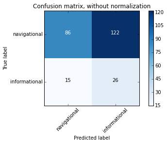

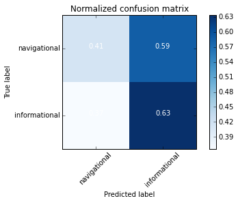

```python
predictedlabels=[]
truelabels=[]
for query, label in allqueriesID:
    try:
        predictedlabels.append(classifier.classify(extractFeatures2(query)))
        truelabels.append(label)
    except:
        IndexError

# Compute confusion matrix
cnf_matrix = confusion_matrix(truelabels, predictedlabels)
np.set_printoptions(precision=2)

# Plot non-normalized confusion matrix
plt.figure()
plot_confusion_matrix(cnf_matrix, classes=class_names,
                      title='Confusion matrix, without normalization')

# Plot normalized confusion matrix

plt.figure()
plot_confusion_matrix(cnf_matrix, classes=class_names, normalize=True,
                      title='Normalized confusion matrix')

plt.show()
```

We can test a few different types of classifiers:

```python
#Decision Tree Classifier
classifier= nltk.classify.DecisionTreeClassifier.train(trainfeatures2)
print 'Decision Tree Classifier'
print nltk.classify.accuracy(classifier, isabelfeatures)

#Support Vector Machine Classifier
classifier = SklearnClassifier(SVC(max_iter=1)).train(trainfeatures2)
print 'Support Vector Machine Classifier'
print nltk.classify.accuracy(classifier, isabelfeatures)

#Logistic Regression
classifier = SklearnClassifier(LogisticRegression(max_iter=1000)).train(trainfeatures2)
print 'Logistic Regression'
print nltk.classify.accuracy(classifier, isabelfeatures)

#K-nearest neighbors
classifier = SklearnClassifier(KNeighborsClassifier()).train(trainfeatures2)
print 'K-nearest neighbors'
print nltk.classify.accuracy(classifier, isabelfeatures)

#Multi-layer perceptron classifier using LBFGS optimization
classifier = SklearnClassifier(MLPClassifier(activation='relu',solver='lbfgs',
                                             alpha=1e-5,hidden_layer_sizes=(5, 4),
                                             random_state=1)).train(trainfeatures2)
#parameters determined through some hyperparameter tuning(not shown)
print 'Multi-layer perceptron classifier'
print nltk.classify.accuracy(classifier, isabelfeatures)
```

```
Decision Tree Classifier
0.638554216867
Support Vector Machine Classifier
0.718875502008
Logistic Regression
0.55421686747
K-nearest neighbors
0.449799196787
Multi-layer perceptron classifier
0.574297188755
```

The decision tree classifier still performs fairly well, as it did on the wellesley searches testing data. Here, the SVM also performs well, suggesting that this model may be good at reducing overfitting to the training data

We can also see how the classifier performs when trained with a more complex set of features, in this case using extractFeatures4, which looks at the similarity of the query and various attributes of the first returned search result, in addition to the features considered by the other feature extractors

```python
#using extractFeatures 4
isabelfeatures4=[]
for (n,g) in allqueriesID:
    try:
        isabelfeatures4.append((extractFeatures4(n),g))
    except:
        IndexError
print len(isabelfeatures4)
with open('isabelfeatures4.txt', 'w') as outfile:
    json.dump(isabelfeatures4, outfile)
```

```
176
```

```python
classifier = nltk.NaiveBayesClassifier.train(trainfeatures4)
print 'Naive Bayes Classifier'
print nltk.classify.accuracy(classifier, isabelfeatures4)

#Decision Tree Classifier
classifier= nltk.classify.DecisionTreeClassifier.train(trainfeatures4)
print 'Decision Tree Classifier'
print nltk.classify.accuracy(classifier, isabelfeatures4)


#Support Vector Machine Classifier
classifier = SklearnClassifier(SVC(max_iter=1)).train(trainfeatures4)
print 'Support Vector Machine Classifier'
print nltk.classify.accuracy(classifier, isabelfeatures4)

#Logistic Regression
classifier = SklearnClassifier(LogisticRegression(max_iter=1000)).train(trainfeatures4)
print 'Logistic Regression'
print nltk.classify.accuracy(classifier, isabelfeatures4)

#K-nearest neighbors
classifier = SklearnClassifier(KNeighborsClassifier()).train(trainfeatures4)
print 'K-nearest neighbors'
print nltk.classify.accuracy(classifier, isabelfeatures4)

#Multi-layer perceptron classifier using LBFGS optimization
classifier = SklearnClassifier(MLPClassifier(activation='relu',solver='lbfgs',
                                             alpha=1e-5,hidden_layer_sizes=(5, 4),
                                             random_state=1)).train(trainfeatures4)
#parameters determined through some hyperparameter tuning(not shown)
print 'Multi-layer perceptron classifier'
print nltk.classify.accuracy(classifier, isabelfeatures4)
```

```
Naive Bayes Classifier
0.488636363636
Decision Tree Classifier
0.221590909091
Support Vector Machine Classifier
0.727272727273
Logistic Regression
0.278409090909
K-nearest neighbors
0.454545454545
Multi-layer perceptron classifier
0.261363636364
```

Here, the support vector machine classifier also performs the best on my own search data, again suggesting that this model is sucessful in avoiding overfitting to the wellesley searches training data

### Summary of Classifier Performance

Below are a set of graphs summarizing the performance of various feature extractors and classifiers tested in this notebook. The testing accuracies reported are the averaged test accuracies obtained using cross-validation.

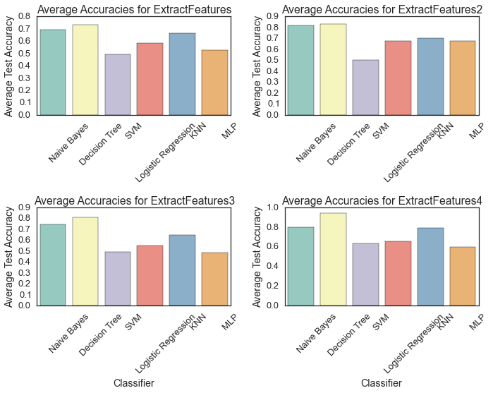

```python
import numpy as np
import matplotlib.pyplot as plt
%matplotlib inline

values1=[0.692,0.733,0.492,0.583,0.667,0.525] #ExtractFeatures
values2=[0.817,0.833,0.500,0.675,0.700,0.675] #ExtractFeatures2
values3=[0.742,0.808,0.492,0.550,0.650,0.483] #ExtractFeatures3
values4=[0.800,0.944,0.633,0.656,0.789,0.600] #ExtractFeatures 4

labels=['Naive Bayes','Decision Tree','SVM','Logistic Regression','KNN','MLP']

import seaborn as sns
sns.set(style="white", context="talk")
indexes = np.arange(len(labels))
width = 1
plt.figure(figsize=(10,8))
plt.subplot(2, 2, 1)
sns.barplot(indexes, values1,palette="Set3")
plt.xticks(indexes + width * 0.5, labels, rotation=45)
plt.ylabel('Average Test Accuracy')
#plt.xlabel('Classifier')
plt.title('Average Accuracies for ExtractFeatures')
plt.subplot(2, 2, 2)
sns.barplot(indexes, values2,palette="Set3")
plt.xticks(indexes + width * 0.5, labels, rotation=45)
plt.ylabel('Average Test Accuracy')
#plt.xlabel('Classifier')
plt.title('Average Accuracies for ExtractFeatures2')
plt.subplot(2, 2, 3)
sns.barplot(indexes, values3,palette="Set3")
plt.xticks(indexes + width * 0.5, labels, rotation=45)
plt.ylabel('Average Test Accuracy')
plt.xlabel('Classifier')
plt.title('Average Accuracies for ExtractFeatures3')
plt.subplot(2, 2, 4)
sns.barplot(indexes, values4,palette="Set3")
plt.xticks(indexes + width * 0.5, labels, rotation=45)
plt.ylabel('Average Test Accuracy')
plt.xlabel('Classifier')
plt.title('Average Accuracies for ExtractFeatures4')
plt.tight_layout()
plt.show()
```